# Airline Results

Loong Kuan

13 January 2017

The results from this data set showcases a functionality I added to use an attribute of the data set to group the data into different windows for analysis.

In this case, I used the attribute `DayOfWeek` to group the data into different consecutive days. Therefore, the window size of 1 represents the drift between days and the window size of 7 represetns drift between weeks.

Note that this does not gurantee that each week starts on a Sunday or Monday.

[interactive chart not shown]

From the `Covariate` graph above, we can see from the daily drift graph that there seems to be a periodic drift that occurs over 2 days. Furthermore, the rate the drift occurs for the first 2 weeks are very similar compared to other weeks. This can be confirmed by the weekly graph as there is low drift at point `120388`, the point between week 1 and 2.

Other than that, it seems that graphs of the other drift types measured has the same rough shape as the `Covariate` graph.

From the `Posterior` graph, the drift measure over individual attributes seems to peak between week 2 and week 3. Furthermore, the drift measured over indivisual attributes between week 3 and week 4 seem to vary more than previously.

Below is the analysis between the data for week 1 to 2 and week 3 to 4.

### Detailed Likelihood (Single Attributes)

[interactive chart not shown]

Individually, there does not seem to be much difference in the `Likelihood` drift between the 2 classes excluding `DayofWeek`. The difference between the drift in `Likelihhod` for the not delayed, `0`, and delayed, `1`, class can be might be duew to the fact data set ended on a period of high drift and possibly a period with a high number of flights, causing flights to be delayed more often.

### Detailed Posterior (Single Attributes)

[interactive chart not shown]

From the analysis, we can observe that not only are `airportForm` and `airportTo` the attributes with the greatest posterior drift, but also that the drift measured is not uniform on all the values of these attributes with a few values of these attributes drifting much more greatly than others. Therefore, this might indicate different airports can vary greatly in its ability to avoid delays.

### Comparing Distribution

#### Between first and second half

```
## [1] "Plots Obtained"
## [1] 8
```

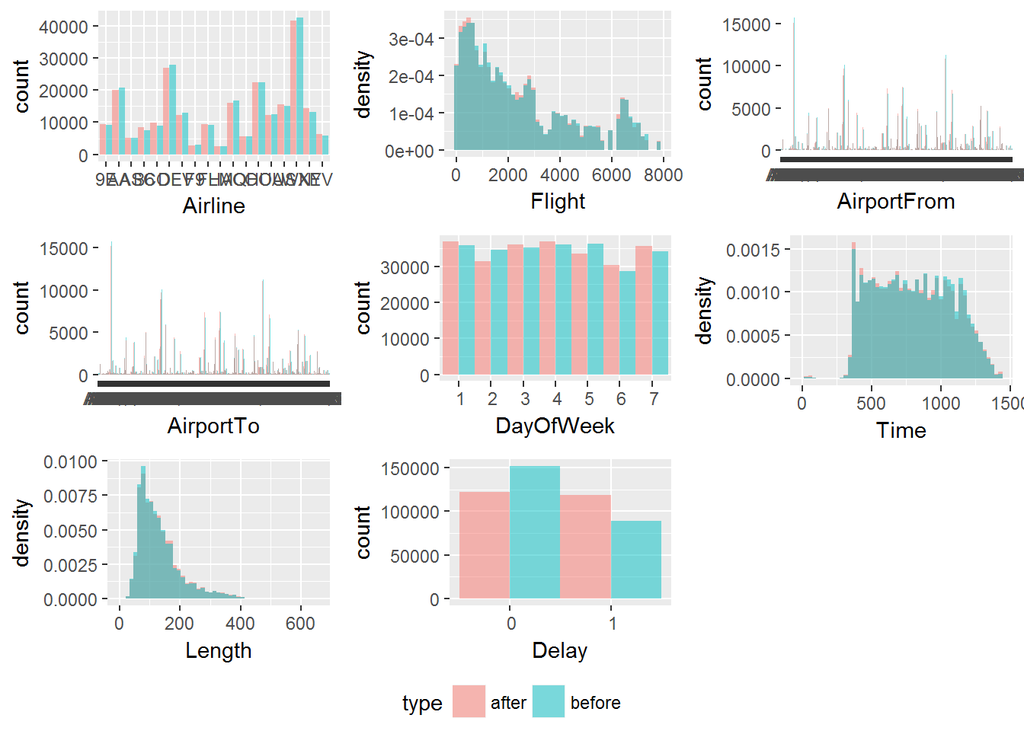

```r
data.all <- read.arff("../../../../../datasets/airlines.arff")
Histogram(data.all[seq(0,240796),], data.all[seq(240797,481594),])
```

#### Between first 2 windows with no drift

```
## [1] "Plots Obtained"
## [1] 8
```

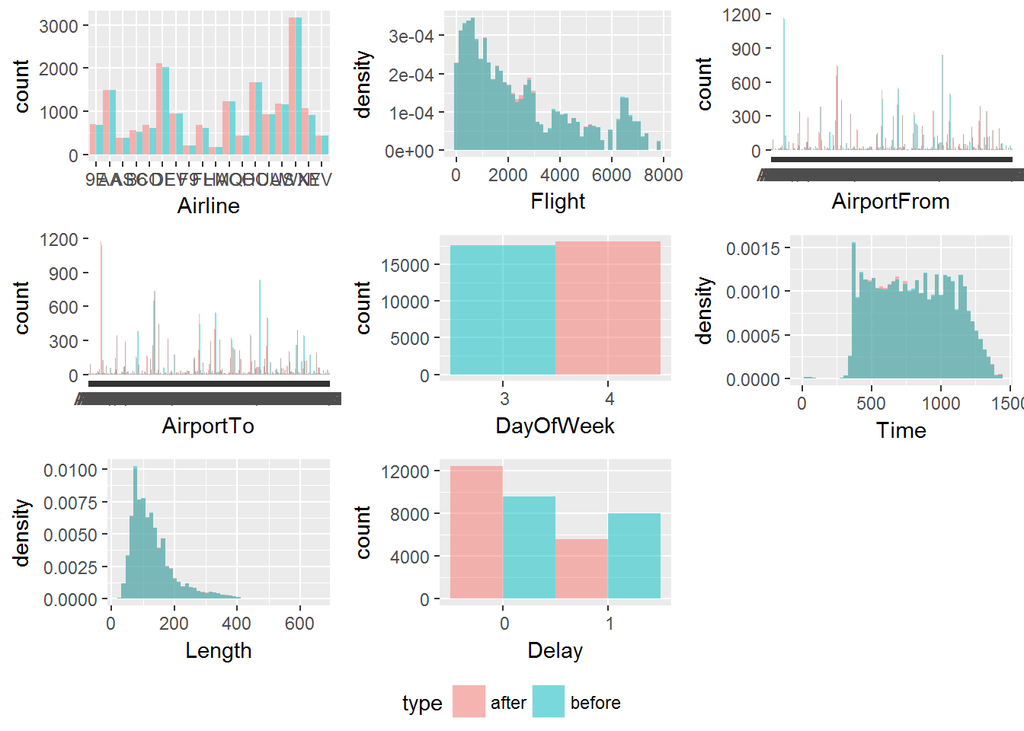

```r
Histogram(data.all[seq(0,17612),], data.all[seq(17613,35659),])
```

#### The first drift peak in the timeline

```
## [1] "Plots Obtained"
## [1] 8
```

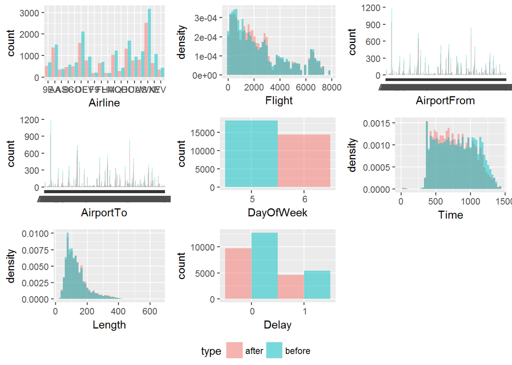

```r
Histogram(data.all[seq(35660,53799),], data.all[seq(53800,68078),])
```

```
## [1] "Plots Obtained"
## [1] 8
```

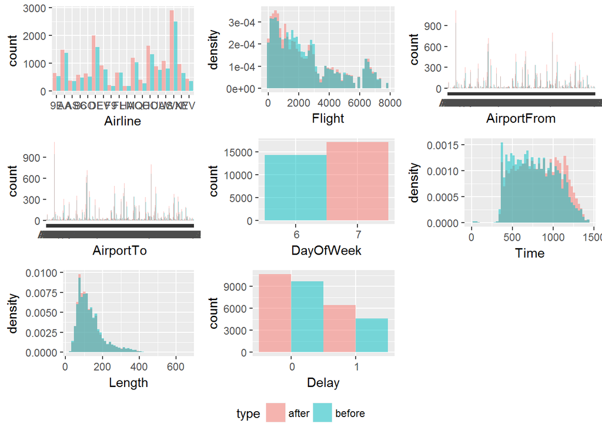

```r
Histogram(data.all[seq(53800,68078),], data.all[seq(68079,85189),])
```

We can observe that there is a big difference between Friday and Saturday and between Saturday and Sunday.

##### The third drift peak in the timeline

```
## [1] "Plots Obtained"
## [1] 8
```

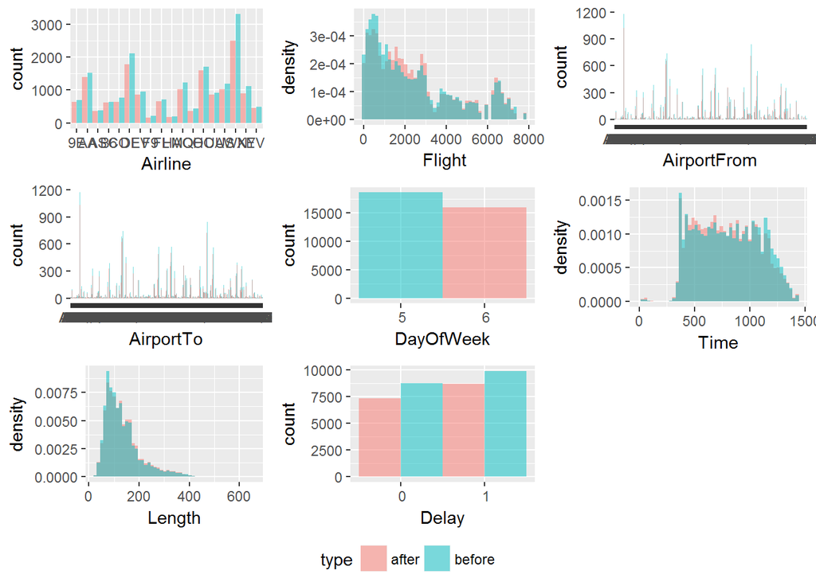

```r
Histogram(data.all[seq(276643,295227),], data.all[seq(295228,311213),])
```

```
## [1] "Plots Obtained"
## [1] 8
```

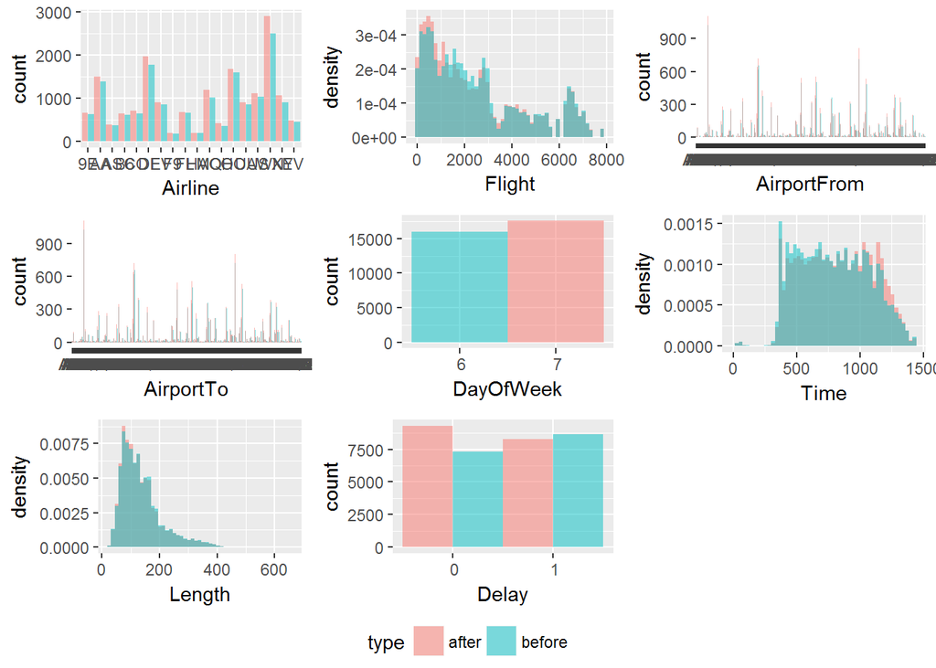

```r
Histogram(data.all[seq(295228,311213),], data.all[seq(311214,328765),])
```